# Programmatic workflow demonstration

This vignette provides an in-depth walk-through of the `MRPWorkflow` and `MRPModel` classes in the **shinymrp** package. You will find practical information about the purpose, arguments, and caveats of each method, enabling you to conduct MRP analyses programmatically.

For an introduction to the package and workflow concepts, begin with the [Getting started with shinymrp](https://mrp-interface.github.io/shinymrp/articles/getting-started.html) vignette.

# Initializing the workflow

MRP analysis begins by instantiating an `MRPWorkflow` object with `mrp_workflow()`. The object-oriented design efficiently manages your data and supports a reproducible workflow without requiring repeated user input. All workflow methods are accessed via the [R6](https://r6.r-lib.org/) `$` operator.

```r
library(shinymrp)
workflow <- mrp_workflow()
```

# 1. Data preparation

MRP requires two key data components:

- **Sample data**: Your analysis sample, which must include the outcome of interest (binary or continuous) and predictors (demographic, geographic, etc.), such as COVID-19 test records or survey responses.
- **Poststratification data**: A table containing population sizes of groups defined by demographic and geographic factors.

For details on accepted formats and preprocessing, see the [Data Preprocessing](https://mrp-interface.github.io/shinymrp/articles/data-prep) vignette.

## 1.1 Preprocessing the sample data

Sample data should be a tidy data frame with your outcome measure and predictors. Time-varying data are also supported, allowing dates or indices (e.g., week, month, or year) to be incorporated for time-varying summaries and estimates.

The `example_sample_data()` function demonstrates accepted structures and common options:

- whether a time variable is included
- whether the data are aggregated
- whether the data follow a specific standard (e.g., medical records from the Epic system)
- whether the outcome measure is binary (modeled with binomial distributions) or continuous (modeled with Gaussian/normal distributions)

```r
sample_data <- example_sample_data(
  is_timevar = TRUE,
  is_aggregated = TRUE,
  special_case = NULL,
  family = "binomial"
)
head(sample_data)
```

```
#> # A tibble: 6 × 10
#>     zip sex    race  age    time county state date       total positive
#>   <dbl> <chr>  <chr> <chr> <dbl>  <dbl> <dbl> <date>     <dbl>    <dbl>
#> 1 71354 female black 0-17      3  22025    22 2020-01-13     1        0
#> 2 71354 female black 0-17      5  22025    22 2020-01-27     1        1
#> 3 71354 female black 0-17      9  22025    22 2020-02-24     1        0
#> 4 71354 female black 18-34     1  22025    22 2019-12-30     2        1
#> 5 71354 female black 18-34     6  22025    22 2020-02-03     1        0
#> 6 71354 female black 18-34     9  22025    22 2020-02-24     1        1
```

Data preprocessing is performed with the `$preprocess()` method, which standardizes formats (e.g., recodes age groups, creates time indices), removes duplicates, and prepares data for modeling.

Note: Only basic cleaning is performed. Conduct preliminary data checks beforehand.

```r
workflow$preprocess(
  sample_data,
  is_timevar = TRUE,
  is_aggregated = TRUE,
  special_case = NULL,
  family = "binomial"
)
```

```
#> Preprocessing sample data...
```

## 1.2 Assembling poststratification data

### 1.2.1 Linking to ACS

Use the `$link_acs()` method to retrieve poststratification data from the American Community Survey (ACS), specifying the desired geographic level and reference year (i.e., the last year of the five-year ACS data collection). Supported levels include ZIP code, county, and state. If not specified, poststratification data are aggregated for the U.S. population.

```r
workflow$link_acs(link_geo = "zip", acs_year = 2021)
```

```
#> Linking data to the ACS...
```

### 1.2.2 Importing custom poststratification data

You can also import your own poststratification data using `$load_pstrat()`. [Requirements](https://mrp-interface.github.io/shinymrp/articles/data-prep#required-columns-and-categories) mirror those for sample data.

```r
pstrat_data <- example_pstrat_data()
workflow$load_pstrat(pstrat_data, is_aggregated = TRUE)
```

```
#> Preprocessing poststratification data...
```

# 2. Descriptive statistics

The `MRPWorkflow` class provides methods for creating visualizations of demographic distributions, geographic coverage, and outcome summaries.

Use `$demo_bars()` to generate bar plots comparing demographic distributions in the sample and poststratification data.

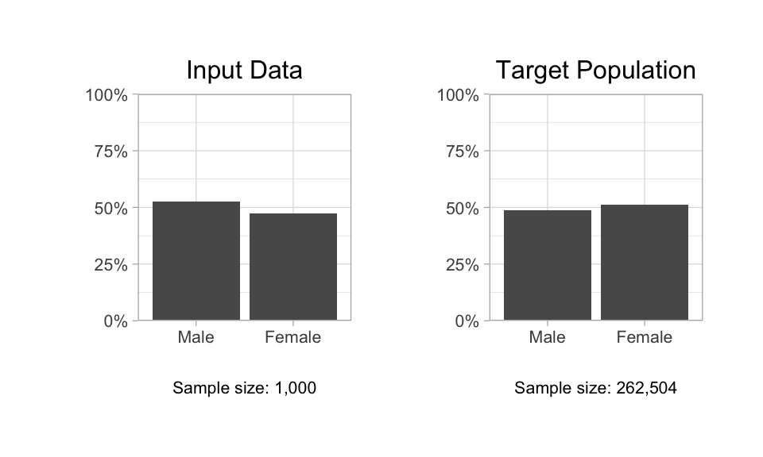

```r
workflow$demo_bars(demo = "sex")
```

For analyzing COVID-19 test data with linked geographic predictors, the `$covar_hist()` method creates frequency histograms of the geographic predictors. This method will give the following error if it is called with incompatible data that do not include geographic predictors.

```r
workflow$covar_hist(covar = "income")
```

```
#> Error in workflow$covar_hist(covar = "income"): Covariate data is not available. This method is only available for COVID data.
```

`$sample_size_map()` visualizes sample sizes across geographic areas in an interactive choropleth map, powered by highcharter.

```r
workflow$sample_size_map()
```

[interactive chart not shown]

`$outcome_plot()` creates plots of average outcome values, including time variation if present.

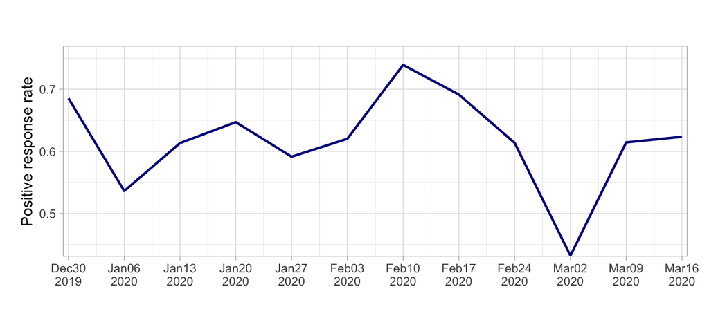

```r
workflow$outcome_plot()
```

`$outcome_map()` visualizes outcome summaries by geography, with options for the maximum or minimum value across time.

```r
workflow$outcome_map(summary_type = "max")
```

[interactive chart not shown]

# 3. Model building

The `MRPModel` class is a wrapper around CmdStanR objects, providing a high-level interface for obtaining posterior summaries and diagnostics.

## 3.1 Model specification

Use `$create_model()` to specify the model, including the mean structure (fixed and varying effects, two-way interactions) and priors. Varying effects assume normal distributions with unknown standard deviations (with specified priors). Stan code is generated for compilation via CmdStanR. Supported prior types include:

- `normal(mu, sigma)`
- `student_t(nu, mu, sigma)`
- `structured` (see [Si et al., 2020](https://www150.statcan.gc.ca/n1/en/pub/12-001-x/2020002/article/00003-eng.pdf?st=iF1_Fbrh))
- `icar` (see [Besag et al., 1991](https://link.springer.com/article/10.1007/BF00116466))
- `bym2` (see [Riebler et al., 2016](https://pubmed.ncbi.nlm.nih.gov/27566770/))

Default priors are used if `""` (empty string) is supplied:

- Overall intercept: normal(0, 5)
- Coefficient: normal(0, 3)
- Standard deviation (main effect): normal<sub>+</sub>(0, 3)
- Standard deviation (interaction): normal<sub>+</sub>(0, 1)

```r
model1 <- workflow$create_model(
  intercept_prior = "normal(0, 4)",
  fixed = list(
    sex = "normal(0, 2)",
    race = "normal(0, 2)"
  ),
  varying = list(
    age = "",
    time = ""
  )
)
```

## 3.2 Model fitting

The `$fit()` method runs Stan’s main Markov chain Monte Carlo algorithm via CmdStanR.

```r
model1$fit(
  n_iter = 500,
  n_chains = 2,
  seed = 123,
  show_messages = FALSE,
  show_exceptions = FALSE
)
```

## 3.3 Posterior summaries and diagnostics

The fitted `MRPModel` object extracts draws from the internal `CmdStanMCMC` object for summaries and diagnostics.

- **Posterior summary and convergence diagnostics**: Use `$summary()` for posterior statistics, effective sample sizes, and R-hat diagnostics.

```r
model1$summary()
```

```
#> $fixed
#>              Estimate Est.Error    l-95% CI  u-95% CI     R-hat Bulk_ESS
#> intercept  -0.1806936 0.2366501 -0.62323136 0.2858898 1.0129243 123.2694
#> sex.male    0.2820848 0.1424741 -0.03302717 0.5607221 1.0058026 387.8492
#> race.black         NA        NA          NA        NA        NA       NA
#> race.other  0.7769749 0.1761400  0.44600155 1.0974148 0.9986902 273.6022
#> race.white  0.8352153 0.1812697  0.45971326 1.1650084 1.0086011 302.6273
#>             Tail_ESS
#> intercept   75.42084
#> sex.male   195.01298
#> race.black        NA
#> race.other 400.95090
#> race.white 286.50056
#>
#> $varying
#>                   Estimate Est.Error   l-95% CI  u-95% CI    R-hat Bulk_ESS
#> age (intercept)  0.2774657 0.2081878 0.03291431 0.9313340 1.014465 155.6559
#> time (intercept) 0.2832033 0.1171988 0.05763138 0.5237029 1.002015 161.9236
#>                  Tail_ESS
#> age (intercept)  217.9925
#> time (intercept) 200.9893
#>
#> $residual
#> data frame with 0 columns and 0 rows
#>
#> $spatial_proportion
#> data frame with 0 columns and 0 rows
```

- **Additional diagnostics**: Use `$diagnostics()` for [detailed diagnostic information](https://mc-stan.org/learn-stan/diagnostics-warnings) about the MCMC process.

```r
model1$diagnostics()
```

```
#>               Metric
#> 1         Divergence
#> 2 Maximum tree depth
#> 3             E-BFMI
#>                                                       Message
#> 1         0 of 500 (0.0%) transitions ended with a divergence
#> 2 0 of 500 transitions hit the maximum tree depth limit of 10
#> 3                   0 of 2 chains had an E-BFMI less than 0.3
```

- **Posterior predictive check**: Use `$pp_check()` to compare posterior predictive samples against observed data.

```r
workflow$pp_check(model1)
```

```
#> Running posterior predictive check...
```

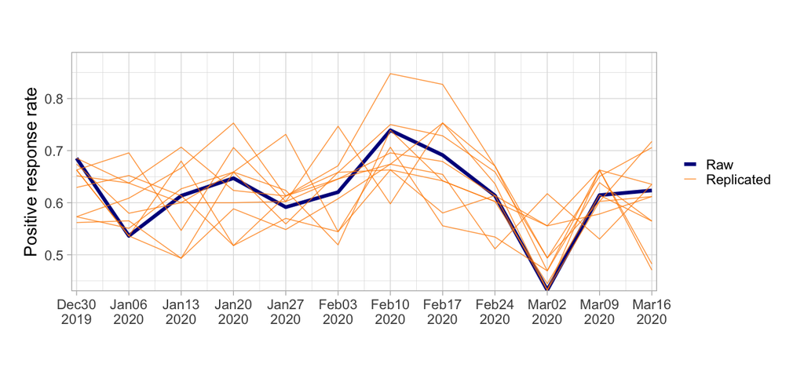

- **Model comparison**: Compare models via leave-one-out cross-validation with `$compare_models()`.

```r
model2 <- workflow$create_model(
  intercept_prior = "normal(0, 4)",
  fixed = list(
    sex = "normal(0, 2)",
    race = "normal(0, 2)"
  ),
  varying = list(
    age = "",
    time = ""
  ),
  interaction = list(
    `age:time` = "normal(0, 1)",
    `race:time` = "normal(0, 1)",
    `sex:time` = "normal(0, 1)"
  )
)

model2$fit(
  n_iter = 500,
  n_chains = 2,
  seed = 123,
  show_messages = FALSE,
  show_exceptions = FALSE
)
workflow$compare_models(model1, model2)
```

```
#> Running leave-one-out cross-validation...
#>         elpd_diff  se_diff
#> model2  0.0000000 0.000000
#> model1 -0.8975559 2.490807
```

## 3.4 Saving and loading models

You can easily save and restore models using the `qs2` package. The `$save()` gathers all posterior draws and diagnostics, then calls `qs2::qs_save()` internally.

```r
model1$save(file = "model1.qs2")

# load back into workspace
model1 <- qs2::qs_read("model1.qs2")
```

# 4. Result visualization

Use `$estimate_plot()` to visualize the model estimates, either overall or by group, with a 95% credible interval by default. Users can specify alternative intervals.

```
#> Running poststratification...
```

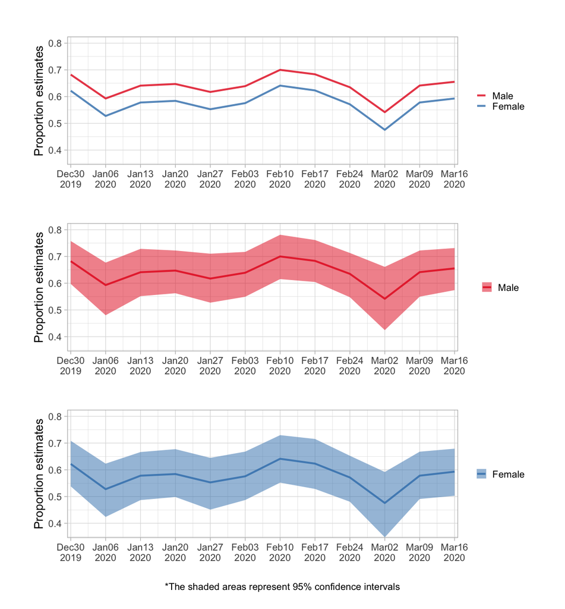

```r
workflow$estimate_plot(model1, group = "sex", interval = 0.95)
```

For time-varying data, `$estimate_map()` creates snapshots of geography-based estimates at specific time points. `time_index` is irrelevant for cross-sectional data.

```r
workflow$estimate_map(model1, geo = "county", interval = 0.95, time_index = 1)
```

[interactive chart not shown]

# Further reading

- [Getting Started with shinymrp](https://mrp-interface.github.io/shinymrp/articles/getting-started.html)
- [Data Preprocessing](https://mrp-interface.github.io/shinymrp/articles/data-prep)
- [Stan Model Diagnostics](https://mc-stan.org/learn-stan/diagnostics-warnings)